# Introduction to data analytics

Fani Apostolidou Kiouti

October, 2021

## The `apply` functions family

Repetitive tasks, over all objects, is one of the primary requirements a language must deal with. for-loops are flow statements that iterate through the elements of the object and evaluate the command defined by the programmer. For example, suppose you want to print every odd number in a vector:

```r
for(i in 751:789) {
  if(!i %% 2){
    next
  }
    print(i)
}
```

```
## [1] 751
## [1] 753
## [1] 755
## [1] 757
## [1] 759
## [1] 761
## [1] 763
## [1] 765
## [1] 767
## [1] 769
## [1] 771
## [1] 773
## [1] 775
## [1] 777
## [1] 779
## [1] 781
## [1] 783
## [1] 785
## [1] 787
## [1] 789
```

In R, for-loops are rather slow; their alternative is the apply family: a series of iterative functions that evaluate a function to the margins of an array or matrix and return a vector or array or list of values.

```r
x <- c(751:789)
x[lapply(x, "%%", 2) == 1]
```

```
##  [1] 751 753 755 757 759 761 763 765 767 769 771 773 775 777 779 781 783 785 787
## [20] 789
```

There are several *apply functions for different input objects and output values. The most commonly used are listed below.

| A function | looping over | and producing |
| --- | --- | --- |
| `apply` | array | vector |
| `lapply` | list | list |
| `sapply` | list | vector;matrix;list |
| `tapply` | subsets of a vector | vector |
| `mapply` | in parallel application over a set of arguments | list |

### apply()

`apply` is a base function used to run the same function over array margins: that is the rows and columns of a matrix (or a multi-dimensional object). The returned value is a *vector* obtained by the above procedure.

This function will turn a data frame into a matrix (using the `as.matrix`) before running the specified function so it should not be used with such objects.

**Syntax**

`apply (X, MARGIN, FUN, ...)`

`X` is any array

`MARGIN` is a vector defining the subscripts over which the `FUN` (function) will run.

**By default, 1 indicates rows, 2 columns and c(1,2) both.**

```r
# Create a two dimensional matrix to work with:
## matrix(data, nrow, ncol, byrow = FALSE, dimnames = NULL)
M <- matrix(seq(1,12), 3, 4)
M
```

```
##      [,1] [,2] [,3] [,4]
## [1,]    1    4    7   10
## [2,]    2    5    8   11
## [3,]    3    6    9   12
```

```r
# apply FUN=min to rows to find the minimum value in each
apply(M, 1, min)
```

```
## [1] 1 2 3
```

```r
# or max to columns to find the maximum value
apply(M, 2, max)
```

```
## [1]  3  6  9 12
```

Arrays with higher dimensions can be handled with apply as well, however indexing is more complicated:

```r
#Build a 3-dimensional array
A <- array(seq(24), dim = c(3,4,2))
A
```

```
## , , 1
##
##      [,1] [,2] [,3] [,4]
## [1,]    1    4    7   10
## [2,]    2    5    8   11
## [3,]    3    6    9   12
##
## , , 2
##
##      [,1] [,2] [,3] [,4]
## [1,]   13   16   19   22
## [2,]   14   17   20   23
## [3,]   15   18   21   24
```

```r
# Apply sum across each A[*, , ] - Note that the returned result is one-dimensional
apply(A, 1, sum) #sum across 2nd and 3rd dimension
```

```
## [1]  92 100 108
```

```r
apply(A, 2, sum) #sum across 1st and 3rd dimension
```

```
## [1]  48  66  84 102
```

```r
apply(A, 3, sum) #sum across 1st and 2nd dimension
```

```
## [1]  78 222
```

```r
# Apply sum across each A[*, *, ] - In this case the result will be two-dimensional
apply(A, c(1,2), sum) #sum across 3rd dimension
```

```
##      [,1] [,2] [,3] [,4]
## [1,]   14   20   26   32
## [2,]   16   22   28   34
## [3,]   18   24   30   36
```

`colMeans, rowMeans, colSums, rowSums` are much simpler alternatives to apply when it comes to summations of such objects:

**Syntax**  
`colSums (x, na.rm = FALSE, dims = 1)`  
`rowSums (x, na.rm = FALSE, dims = 1)`  
`colMeans(x, na.rm = FALSE, dims = 1)`  
`rowMeans(x, na.rm = FALSE, dims = 1)`

`x` an **array** of two or more dimensions, containing numeric, complex, integer or logical values, or a **numeric data frame**.

`na.rm` is a logical defining wether missing values will be omitted from the calculations or not

`dims` is an integer declaring the dimensions to be regarded as “rows” or “columns” to sum over.

To use the above functions with a matrix, the syntax is a bit different:  
`.colSums(X, m, n, na.rm = FALSE)`  
`.rowSums(X, m, n, na.rm = FALSE)`  
`.colMeans(X, m, n, na.rm = FALSE)`  
`.rowMeans(X, m, n, na.rm = FALSE)`

`X` a numeric matrix

`m, n` the dimensions of X

### lapply()

`lapply` is used to apply a function to each element of a list in turn and get a list as a returned value.

```r
#Create a list, L
L <- list(d = 8, m = c(T,F,T), y = 1:13)
L
```

```
## $d
## [1] 8
##
## $m
## [1]  TRUE FALSE  TRUE
##
## $y
##  [1]  1  2  3  4  5  6  7  8  9 10 11 12 13
```

Apply the length function on L’s elements to see the number of values in each

```r
lapply(L, FUN = length)
```

```
## $d
## [1] 1
##
## $m
## [1] 3
##
## $y
## [1] 13
```

```r
lapply(L, FUN = sum) #Apply the sum function for summation in each element
```

```
## $d
## [1] 8
##
## $m
## [1] 2
##
## $y
## [1] 91
```

Note that lapply() will pass the elements from the list as the **first** argument to the function. More arguments can be defined after that.

```r
lapply(1:3, runif, min = 6, max = 7)
```

```
## [[1]]
## [1] 6.012753
##
## [[2]]
## [1] 6.978614 6.233246
##
## [[3]]
## [1] 6.785070 6.988411 6.898290
```

```r
# runif(n, min, max) generates n random
# deviates from the uniform distribution on the interval(min, max).
```

One can also use anonymous functions within lapply. Suppose one wants to calculate the coefficient of variation in the columns of a random dataframe, df:

```r
# a random dataframe using, again, the uniform distribution
df <- as.data.frame(cbind(runif(100, 2,3), runif(100, 5,6)))
 # CV equals the standard deviation divided by the mean
lapply(df, function(x) x = sd(x)/mean(x))
```

```
## $V1
## [1] 0.1161585
##
## $V2
## [1] 0.05347908
```

What does anonymous mean? An anonymous function is an invisible one; it is evaluated, it produces a value and then it disappears from the environment. You cannot call it back, you cannot iterate other objects through it, in other words it is evaluated in the global environment but it is not stored anywhere. A good rule of thumb is that an anonymous function should fit on one line and should not require {}. It is not advisable to use anonymous functions but to separately define them when they grow too long and require intermediate objects.

### sapply() and tapply()

`sapply` is used for lists just as `lapply` but returns a vector back

```r
sapply(L, FUN = sum)
```

```
##  d  m  y
##  8  2 91
```

`sapply` significantly expands its functionality in combination with the base function `split(x, f)`. `split()` divides the input (x) according to groups (f).

```r
V <- c(o = 1, e = 6, o = 3, e = 12, o = 5)
split(V, names(V))
```

```
## $e
##  e  e
##  6 12
##
## $o
## o o o
## 1 3 5
```

```r
#Split according to another grouping factor, defined separately
m3 <- c("Non3", "M3", "M3", "M3", "Non3")
split(V, m3)
```

```
## $M3
##  e  o  e
##  6  3 12
##
## $Non3
## o o
## 1 5
```

```r
#Combine the two grouping variables in a single interaction
split(V, list(names(V), m3))
```

```
## $e.M3
##  e  e
##  6 12
##
## $o.M3
## o
## 3
##
## $e.Non3
## named numeric(0)
##
## $o.Non3
## o o
## 1 5
```

```r
split(V, list(names(V), m3), drop = T)
```

```
## $e.M3
##  e  e
##  6 12
##
## $o.M3
## o
## 3
##
## $o.Non3
## o o
## 1 5
```

```r
#Using a split function to calculate the means in each subset of interactions in V
sapply(split(V, list(names(V), m3)), mean)
```

```
##   e.M3   o.M3 e.Non3 o.Non3
##      9      3    NaN      3
```

`tapply` applies a function to subsets of a vector which are defined by another vector and returns a table, instead of a vector.

```r
tapply(V, list(names(V), m3), mean)
```

```
##   M3 Non3
## e  9   NA
## o  3    3
```

### mapply()

`mapply` is a multivariate version of sapply. This means that it can apply the function to multiple lists or multiple vector arguments. Its main difference with the other applies is that its first argument is the function to be evaluated.

```r
mapply(mean, L)
```

```
##         d         m         y
## 8.0000000 0.6666667 7.0000000
```

```r
mapply(matrix, list(x = runif(12, 3, 5), y = 1:6, z = 1), nrow = c(3, 2, 12))
```

```
## $x
##          [,1]    [,2]     [,3]     [,4]
## [1,] 4.255784 4.00058 4.780145 3.972053
## [2,] 4.914424 4.86930 3.442019 4.166006
## [3,] 3.883465 4.80403 4.825235 4.201276
##
## $y
##      [,1] [,2] [,3]
## [1,]    1    3    5
## [2,]    2    4    6
##
## $z
##       [,1]
##  [1,]    1
##  [2,]    1
##  [3,]    1
##  [4,]    1
##  [5,]    1
##  [6,]    1
##  [7,]    1
##  [8,]    1
##  [9,]    1
## [10,]    1
## [11,]    1
## [12,]    1
```

```r
# The alternative would be syntaxed as follows:
#list(x = matrix(runif(12, 3, 5), nrow = 3, byrow = T),
#     y = matrix(1:6, nrow = 2, byrow = T),
#     z = matrix(1, nrow = 12, byrow = T))
# mapply can also be used to create a new variable from existing ones
df$V3 <- mapply(function(x,y) x^2/y, df$V1, df$V2)
df
```

| V1 | V2 | V3 |
| --- | --- | --- |
| 2.809734 | 5.722019 | 1.3796890 |
| 2.412380 | 5.679090 | 1.0247380 |
| 2.106998 | 5.864661 | 0.7569819 |
| 2.622484 | 5.547928 | 1.2396378 |
| 2.388131 | 5.984467 | 0.9529952 |
| 2.064474 | 5.172170 | 0.8240361 |
| 2.663483 | 5.525059 | 1.2839939 |
| 2.914085 | 5.657376 | 1.5010304 |
| 2.722436 | 5.225515 | 1.4183592 |
| 2.932085 | 5.310445 | 1.6189078 |

[output cut: 90 more lines]

Additional apply members are `eapply`, `rapply` and `vapply`. eapply applies FUN to the named values from an environment and returns the results as a list. The user can request that all named objects are used (normally names that begin with a dot are not). The output is not sorted and no enclosing environments are searched. `rapply` is a recursive version of lapply with flexibility on the structure of the output via the argument how = “list;unlist;replace”. Finally, `vapply` is the alternative to sapply when one wants to define the output value, both its type and length.

## Iterations and functional programming

Data aggregation, the derivation of several metrics for variables, is a fundamental task in analytics. The above section introduced the idea of iteration; repetition of the same task under conditions. Iteration is repetition. Functional programming is a process in which tasks are performed by applying mathematical functions. Base R fulfills the task with the apply family, indexing and anonymous functions. Integration with other languages and increasing data size has resulted into the development of more complex data tools, including the introduction of new operators and verbs. Among these, the introduction of tidy tables allowed for the development of iterating functions with more convenient syntax. The three packages that follow include the tools for the above, namely the `map` functions, the pipe operator `%>%` and the data aggregation grammar of `dplyr`.

### {purrr}, {magritrr}

```r
library(purrr);library(magrittr)
```

Pipes are used to pass information (or data) from one program process to another sequentially. Therefore, the pipe operator `%>%` is essentially a function. Behind the scenes, the operator translates the readable code into a form with intermediate objects to facilitate execution.

```r
# Display the first 6 rows
df %>%
  head()
```

|  | V1 | V2 | V3 |
| --- | --- | --- | --- |
| 1 | 2.809734 | 5.722019 | 1.3796890 |
| 2 | 2.412380 | 5.679090 | 1.0247380 |
| 3 | 2.106998 | 5.864661 | 0.7569819 |
| 4 | 2.622484 | 5.547928 | 1.2396378 |
| 5 | 2.388131 | 5.984467 | 0.9529952 |
| 6 | 2.064474 | 5.172170 | 0.8240361 |

Pipes are very convenient, but there are a few limitations in their use:

- Multidirectional relationships cannot be piped.
- A pipe can only transfer one object at a time.
- Lazy evaluation (that is, computation of an argument only when the function is evaluated) is unstable with pipes
- They use a temporary environment (to save intermediate objects); if a function uses the current environment it should be explicitly stated in the code: `env <- environment()...`

{purrr} offers a variety of functions, similar to the apply family, to execute repetitive tasks over vectors or lists and return lists.

| function | objects |
| --- | --- |
| map_* | list or vector |
| map2_* | pairs of elements from two lists or vectors |
| pmap_* | groups of elements from a list of lists or vectors |
| imap_* | apply a function to each element and its index |

The * corresponds to the returned value structure and stands for: - `dbl` double - `int` integer - `chr` character - `lgl` logical - `dfc` dataframe (from cbind) - `dfr` dataframe (from rbind)

```r
# Using a pipe and a map function to derive means for all variables in df
df %>%
  map_dbl(mean)
```

```
##       V1       V2       V3
## 2.548082 5.492438 1.201606
```

```r
# Using only the map function for the standard deviations
map_dbl(df, sd)
```

```
##        V1        V2        V3
## 0.2959813 0.2937306 0.2811397
```

What if we had a more complex dataset, for which we want to inspect elements, derive some measures, inspect plots and calculate a new variable?

```r
# Impute numeric values from the normal distribution:
## First, define means (we aim for 3 num variables, therefore three means)
mu <- list(50, 1300, 36)
## Define their standard deviations
sigma <- list(5, 250, 2)
## Combine them into one list (20 corresponds to the number of observations - it is arbitrary)
nums <- list(20, mu, sigma)
## Now, use pmap_dfc to iterate through the values of the num list and calculate random values from the normal distribution
nums %<>%
  pmap_dfc(rnorm)
```

```
## * NA -> ...1
## * NA -> ...2
## * NA -> ...3
```

```r
## Name the newly born variables
names(nums) <- c("age", "brthw", "brtha")
# Create a data frame with the numericals, and ID variable and an arbitrary gender variable
dtfr <- data.frame(id = c(1:20),
                   gender = rep(c("m","f"), 10),
                   nums
  )
dtfr$gender <- as.factor(dtfr$gender)

## Reasonably, one would like to calculate metrics for the whole dataset
map_dbl(dtfr, mean)
```

```
##         id     gender        age      brthw      brtha
##   10.50000         NA   51.43169 1267.65505   36.77519
```

```r
# and then look for correlations among variables - in this case, birth weight by birth age in the gender categories.
dtfr %>%
  split(.$gender) %>%
  map(~lm(brthw ~ brtha, data = .))
```

```
## $f
##
## Call:
## lm(formula = brthw ~ brtha, data = .)
##
## Coefficients:
## (Intercept)        brtha
##      674.52        16.84
##
##
## $m
##
## Call:
## lm(formula = brthw ~ brtha, data = .)
##
## Coefficients:
## (Intercept)        brtha
##    -1221.78        66.17
```

```r
# One may wish to call for another calculated value from the lm formula, in this example we call for the R-squared for each model.
dtfr %>%
  split(.$gender) %>%
  map(~lm(brthw ~ brtha, data = .)) %>%
  map(summary) %>%
  map_dbl(~.$r.squared)
```

```
##           f           m
## 0.009624109 0.205255419
```

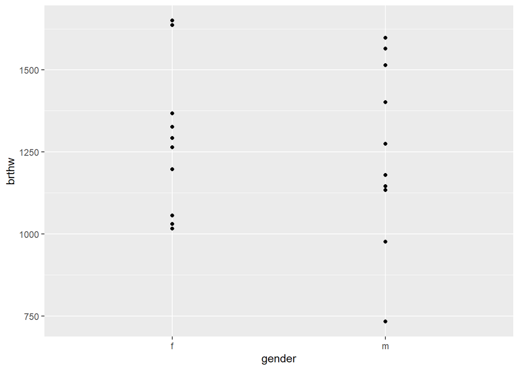

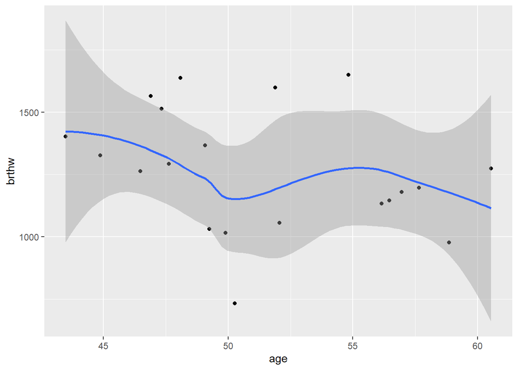

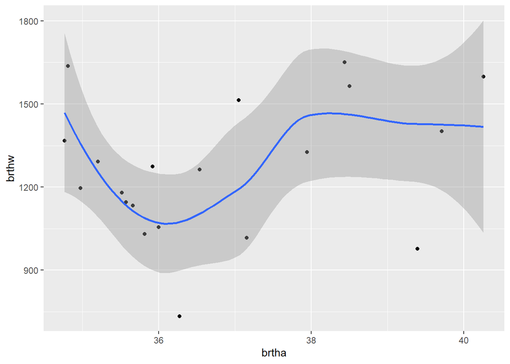

```r
# Creating multiple plots
## First, choose the variable names from the dataset, to inform the map() on what to iterate. rspn for the response variable, expl for the explanatory variables
rspn <- names(dtfr)[4]
expl <- names(dtfr)[c(2,3,5)]
# Then define a plotting function
library(ggplot2)
scat.fn = function(x, y) {
     ggplot(dtfr, aes(x = .data[[x]], y = .data[[y]]) ) +
          geom_point() +
          geom_smooth(method = "loess")
}
# Now use map, to iterate over expl elements and evaluate the function scatter_fun
map(expl, ~scat.fn(.x, "brthw") )
```

### {dplyr}

```r
library(dplyr)
```

| verb | function |
| --- | --- |
| mutate() | add new variables computed from existing variables |
| transmute() | compute new columns and drop the original ones |
| select() | pick variables based on their names |
| filter() | pick cases based on their values |
| summarise() | reduce multiple values down to a single summary |
| arrange() | change the ordering of the rows |
| group_by() | group by a vector |
| across() | summarise multiple columns in the same way |

The best way to explore the dplyr verbs is to see them into action.

## Aggregating data with a grammar

### Practice with a database

```r
irsrd <- select(irs, -ID)
glimpse(irsrd)
```

```
## Rows: 52
## Columns: 5
## $ systolic.pressure  <dbl> 144.5, 143.3, 150.1, 141.1, 144.0, 137.6, 142.1, 14~
## $ diastolic.pressure <dbl> 72.0, 78.2, 73.9, 61.7, 61.4, 73.4, 79.2, 66.6, 82.~
## $ sodium.excretion   <dbl> 149.3, 133.0, 142.6, 5.8, 0.2, 148.9, 184.3, 194.1,~
## $ country            <chr> "Argentina", "Belgium", "Belgium", "Brazil", "Brazi~
## $ gender             <chr> "M", "M", "M", "F", "F", "F", "M", "F", "F", "F", "~
```

```r
# use the assignment pipe operator %<>%
irsrd %<>%
  mutate(map = (systolic.pressure/3 + diastolic.pressure))
```

### Selecting rows and columns with criteria or by position:

Select rows with logical criteria

```r
filter(irsrd, sodium.excretion > 150)
```

| systolic.pressure | diastolic.pressure | sodium.excretion | country | gender | map |
| --- | --- | --- | --- | --- | --- |
| 142.1 | 79.2 | 184.3 | Canada | M | 126.5667 |
| 144.7 | 66.6 | 194.1 | Colombia | F | 114.8333 |
| 144.9 | 77.5 | 164.1 | Finland | F | 125.8000 |
| 146.0 | 79.2 | 189.7 | Hungary | F | 127.8667 |
| 134.3 | 70.7 | 194.4 | India | M | 115.4667 |
| 144.4 | 73.9 | 153.2 | India | M | 122.0333 |
| 149.1 | 79.6 | 175.9 | Italy | F | 129.3000 |
| 149.2 | 69.9 | 169.9 | Italy | F | 119.6333 |
| 140.2 | 76.0 | 170.0 | Italy | F | 122.7333 |
| 134.2 | 72.9 | 162.6 | Italy | F | 117.6333 |

[output cut: 17 more lines]

Remove duplicates

```r
distinct(irsrd)
```

| systolic.pressure | diastolic.pressure | sodium.excretion | country | gender | map |
| --- | --- | --- | --- | --- | --- |
| 144.5 | 72.0 | 149.3 | Argentina | M | 120.1667 |
| 143.3 | 78.2 | 133.0 | Belgium | M | 125.9667 |
| 150.1 | 73.9 | 142.6 | Belgium | M | 123.9333 |
| 141.1 | 61.7 | 5.8 | Brazil | F | 108.7333 |
| 144.0 | 61.4 | 0.2 | Brazil | F | 109.4000 |
| 137.6 | 73.4 | 148.9 | Canada | F | 119.2667 |
| 142.1 | 79.2 | 184.3 | Canada | M | 126.5667 |
| 144.7 | 66.6 | 194.1 | Colombia | F | 114.8333 |
| 136.1 | 82.1 | 135.6 | Denmark | F | 127.4667 |
| 137.4 | 75.0 | 138.7 | Germany | F | 120.8000 |

[output cut: 42 more lines]

Select rows by position

```r
slice(irsrd, 21:35)
```

| systolic.pressure | diastolic.pressure | sodium.excretion | country | gender | map |
| --- | --- | --- | --- | --- | --- |
| 143.5 | 68.4 | 167.1 | Japan | M | 116.2333 |
| 137.2 | 67.2 | 171.2 | Japan | M | 112.9333 |
| 156.6 | 73.5 | 201.2 | Japan | M | 125.7000 |
| 140.5 | 67.9 | 51.3 | Kenya | F | 114.7333 |
| 144.8 | 77.2 | 165.6 | Malta | M | 125.4667 |
| 149.0 | 72.6 | 134.6 | Mexico | M | 122.2667 |
| 148.5 | 79.7 | 146.4 | Netherlands | M | 129.2000 |
| 160.4 | 62.9 | 26.8 | Papua New Guinea | F | 116.3667 |
| 146.1 | 66.1 | 196.4 | China | M | 114.8000 |
| 158.7 | 67.4 | 158.1 | China | M | 120.3000 |

[output cut: 5 more lines]

Select columns whose name contains a character string

```r
select(irsrd, contains("s"))
```

| systolic.pressure | diastolic.pressure | sodium.excretion |
| --- | --- | --- |
| 144.5 | 72.0 | 149.3 |
| 143.3 | 78.2 | 133.0 |
| 150.1 | 73.9 | 142.6 |
| 141.1 | 61.7 | 5.8 |
| 144.0 | 61.4 | 0.2 |
| 137.6 | 73.4 | 148.9 |
| 142.1 | 79.2 | 184.3 |
| 144.7 | 66.6 | 194.1 |
| 136.1 | 82.1 | 135.6 |
| 137.4 | 75.0 | 138.7 |

[output cut: 42 more lines]

Select columns whose name starts or ends with a character string

```r
select(irsrd, starts_with("s"))
```

| systolic.pressure | sodium.excretion |
| --- | --- |
| 144.5 | 149.3 |
| 143.3 | 133.0 |
| 150.1 | 142.6 |
| 141.1 | 5.8 |
| 144.0 | 0.2 |
| 137.6 | 148.9 |
| 142.1 | 184.3 |
| 144.7 | 194.1 |
| 136.1 | 135.6 |
| 137.4 | 138.7 |

[output cut: 42 more lines]

```r
select(irsrd, ends_with("re"))
```

| systolic.pressure | diastolic.pressure |
| --- | --- |
| 144.5 | 72.0 |
| 143.3 | 78.2 |
| 150.1 | 73.9 |
| 141.1 | 61.7 |
| 144.0 | 61.4 |
| 137.6 | 73.4 |
| 142.1 | 79.2 |
| 144.7 | 66.6 |
| 136.1 | 82.1 |
| 137.4 | 75.0 |

[output cut: 42 more lines]

Select all columns between sodium.excretion and map (inclusive)

```r
select(irsrd, sodium.excretion:map)
```

| sodium.excretion | country | gender | map |
| --- | --- | --- | --- |
| 149.3 | Argentina | M | 120.1667 |
| 133.0 | Belgium | M | 125.9667 |
| 142.6 | Belgium | M | 123.9333 |
| 5.8 | Brazil | F | 108.7333 |
| 0.2 | Brazil | F | 109.4000 |
| 148.9 | Canada | F | 119.2667 |
| 184.3 | Canada | M | 126.5667 |
| 194.1 | Colombia | F | 114.8333 |
| 135.6 | Denmark | F | 127.4667 |
| 138.7 | Germany | F | 120.8000 |

[output cut: 42 more lines]

Arragne in different orders

```r
irsrd %>%
  arrange(desc(gender)) %>%
  arrange(country)
```

| systolic.pressure | diastolic.pressure | sodium.excretion | country | gender | map |
| --- | --- | --- | --- | --- | --- |
| 144.5 | 72.0 | 149.3 | Argentina | M | 120.1667 |
| 143.3 | 78.2 | 133.0 | Belgium | M | 125.9667 |
| 150.1 | 73.9 | 142.6 | Belgium | M | 123.9333 |
| 141.1 | 61.7 | 5.8 | Brazil | F | 108.7333 |
| 144.0 | 61.4 | 0.2 | Brazil | F | 109.4000 |
| 142.1 | 79.2 | 184.3 | Canada | M | 126.5667 |
| 137.6 | 73.4 | 148.9 | Canada | F | 119.2667 |
| 146.1 | 66.1 | 196.4 | China | M | 114.8000 |
| 158.7 | 67.4 | 158.1 | China | M | 120.3000 |
| 141.1 | 70.2 | 242.1 | China | F | 117.2333 |

[output cut: 42 more lines]

```r
  #arrange(country) implies ascending order; descending must be specified
irsrd %>%
  arrange(gender)  %>%
  select(systolic.pressure, map, country)
```

| systolic.pressure | map | country |
| --- | --- | --- |
| 141.1 | 108.7333 | Brazil |
| 144.0 | 109.4000 | Brazil |
| 137.6 | 119.2667 | Canada |
| 144.7 | 114.8333 | Colombia |
| 136.1 | 127.4667 | Denmark |
| 137.4 | 120.8000 | Germany |
| 144.9 | 125.8000 | Finland |
| 146.0 | 127.8667 | Hungary |
| 149.1 | 129.3000 | Italy |
| 149.2 | 119.6333 | Italy |

[output cut: 42 more lines]

Computations with criteria:

```r
library(countrycode)
cont <- data.frame(country = irsrd$country)
cont$continent <- countrycode(sourcevar = cont[, "country"],
                            origin = "country.name",
                            destination = "continent")
irsrd %>%
  group_by(cont$continent) %>% # note that we are working in a different
                              # environment now, the pipe will not work unless
                              # we define the destination of the continent variable
  select(contains("p")) %>%
  summarise(mean(map))
```

| cont$continent | mean(map) |
| --- | --- |
| Africa | 119.2833 |
| Americas | 121.4738 |
| Asia | 119.6467 |
| Europe | 123.1533 |
| Oceania | 116.3667 |

```r
# how about calculating all means?
irsrd %>%
  group_by(cont$continent) %>%
  select(contains("p")) %>%
  map_dbl(mean)
```

```
##     cont$continent  systolic.pressure diastolic.pressure                map
##                 NA          145.78654           73.15192          121.74744
```

## Interchanging formats

Suppose we need a combined variable of blood pressures (systolic and diastolic). To form this variable we need a function that will duplicate the rows but will also create a new one, defining the original observation as either systolic or diastolic. The function in `tidyr` is `gather(key, value, ...)`. The *key* variable will be created from the function by default to store the column name in which each value originally belonged. The *value* variable will be our new variable, the one containing all pressures.

```r
irsrd %<>%
  tidyr::gather(key = "sample", value = "pressures", systolic.pressure, diastolic.pressure)

# alternative
#irsrd %>%
#  tidyr::pivot_longer(cols = 1:2, names_to = "pressures", values_to = "metric")

glimpse(irsrd)
```

```
## Rows: 104
## Columns: 6
## $ sodium.excretion <dbl> 149.3, 133.0, 142.6, 5.8, 0.2, 148.9, 184.3, 194.1, 1~
## $ country          <chr> "Argentina", "Belgium", "Belgium", "Brazil", "Brazil"~
## $ gender           <chr> "M", "M", "M", "F", "F", "F", "M", "F", "F", "F", "F"~
## $ map              <dbl> 120.1667, 125.9667, 123.9333, 108.7333, 109.4000, 119~
## $ sample           <chr> "systolic.pressure", "systolic.pressure", "systolic.p~
## $ pressures        <dbl> 144.5, 143.3, 150.1, 141.1, 144.0, 137.6, 142.1, 144.~
```

```r
nrow(irsrd)
```

```
## [1] 104
```

To invert this function, use `spread()`.

```r
tidyr::spread(irsrd, key = sample, value = pressures) # no characters this time
```

| sodium.excretion | country | gender | map | diastolic.pressure | systolic.pressure |
| --- | --- | --- | --- | --- | --- |
| 0.2 | Brazil | F | 109.4000 | 61.4 | 144.0 |
| 5.8 | Brazil | F | 108.7333 | 61.7 | 141.1 |
| 26.8 | Papua New Guinea | F | 116.3667 | 62.9 | 160.4 |
| 51.3 | Kenya | F | 114.7333 | 67.9 | 140.5 |
| 95.9 | USA | M | 132.7667 | 78.5 | 162.8 |
| 108.3 | Trinidad | F | 127.4667 | 75.5 | 155.9 |
| 125.9 | USA | F | 118.9333 | 72.4 | 139.6 |
| 129.7 | Zimbabwe | M | 123.8333 | 75.6 | 144.7 |
| 130.3 | USA | F | 124.0000 | 73.2 | 152.4 |
| 133.0 | Belgium | M | 125.9667 | 78.2 | 143.3 |

[output cut: 42 more lines]

```r
# alternate functions
#tidyr::pivot_wider(irsrd, names_from = pressures, values_from = metric)
```